# Neo_final

```python
import pandas as pd
import numpy as np
import matplotlib.pyplot as plt
from matplotlib import rcParams
import seaborn as sns
import category_encoders as ce  # Leave-one-out, CatBoost, Heimert coding
from sklearn.preprocessing import StandardScaler  # label encoder, 標準化
from sklearn.cluster import DBSCAN  # outlier detection
from sklearn.model_selection import train_test_split, GridSearchCV  # split data into train data & test data

import warnings
warnings.filterwarnings('ignore')
plt.rcParams['axes.labelsize'] = 14
plt.rcParams['axes.titlesize'] = 16
plt.rcParams['figure.titlesize'] = 16
plt.rcParams['xtick.labelsize'] = 12
plt.rcParams['ytick.labelsize'] = 12
plt.rcParams['legend.fontsize'] = 10
```

```python
#基本不更動raw_data, 之後都用df操作
```

```python
raw_data = pd.read_csv('train.csv').drop(['policy_id'], axis=1)
display(df.head())
print('The dimension of train dataset: ', raw_data.shape)
raw_data['is_claim'].value_counts()
```

[output not shown]

5 rows × 43 columns

```
The dimension of train dataset:  (58592, 43)
```

```
0    54844
1     3748
Name: is_claim, dtype: int64
```

-嚴重的 **data imbalanced-**

約1:15

```python
raw_data.describe()
```

|  | policy_tenure | age_of_car | age_of_policyholder | population_density | make | airbags | displacement | cylinder | gear_box | turning_radius | length | width | height | gross_weight | ncap_rating | is_claim |
| --- | --- | --- | --- | --- | --- | --- | --- | --- | --- | --- | --- | --- | --- | --- | --- | --- |
| count | 58592.000000 | 58592.000000 | 58592.000000 | 58592.000000 | 58592.000000 | 58592.000000 | 58592.000000 | 58592.000000 | 58592.000000 | 58592.000000 | 58592.000000 | 58592.000000 | 58592.00000 | 58592.000000 | 58592.000000 | 58592.000000 |
| mean | 0.611246 | 0.069424 | 0.469420 | 18826.858667 | 1.763722 | 3.137066 | 1162.355851 | 3.626963 | 5.245443 | 4.852893 | 3850.476891 | 1672.233667 | 1553.33537 | 1385.276813 | 1.759950 | 0.063968 |
| std | 0.414156 | 0.056721 | 0.122886 | 17660.174792 | 1.136988 | 1.832641 | 266.304786 | 0.483616 | 0.430353 | 0.228061 | 311.457119 | 112.089135 | 79.62227 | 212.423085 | 1.389576 | 0.244698 |
| min | 0.002735 | 0.000000 | 0.288462 | 290.000000 | 1.000000 | 1.000000 | 796.000000 | 3.000000 | 5.000000 | 4.500000 | 3445.000000 | 1475.000000 | 1475.00000 | 1051.000000 | 0.000000 | 0.000000 |
| 25% | 0.210250 | 0.020000 | 0.365385 | 6112.000000 | 1.000000 | 2.000000 | 796.000000 | 3.000000 | 5.000000 | 4.600000 | 3445.000000 | 1515.000000 | 1475.00000 | 1185.000000 | 0.000000 | 0.000000 |
| 50% | 0.573792 | 0.060000 | 0.451923 | 8794.000000 | 1.000000 | 2.000000 | 1197.000000 | 4.000000 | 5.000000 | 4.800000 | 3845.000000 | 1735.000000 | 1530.00000 | 1335.000000 | 2.000000 | 0.000000 |
| 75% | 1.039104 | 0.110000 | 0.548077 | 27003.000000 | 3.000000 | 6.000000 | 1493.000000 | 4.000000 | 5.000000 | 5.000000 | 3995.000000 | 1755.000000 | 1635.00000 | 1510.000000 | 3.000000 | 0.000000 |
| max | 1.396641 | 1.000000 | 1.000000 | 73430.000000 | 5.000000 | 6.000000 | 1498.000000 | 4.000000 | 6.000000 | 5.200000 | 4300.000000 | 1811.000000 | 1825.00000 | 1720.000000 | 5.000000 | 1.000000 |

```python
percentage_result = raw_data.isnull().sum()/raw_data.shape[0]
percentage_result = pd.DataFrame({"missing": percentage_result}) #"columns": percentage_result.keys(),
percentage_result.sort_values(by='missing', ascending=False).head()
```

|  | missing |
| --- | --- |
| policy_tenure | 0.0 |
| is_rear_window_defogger | 0.0 |
| turning_radius | 0.0 |
| length | 0.0 |
| width | 0.0 |

可以知道 **沒有資料缺失**，接著處理類別變數  
發現眾多欄位包含Yes/No, 將其與其他類別變數分開處理  
處理順序：先編碼(encode)，再分割訓練測試集(split)，再標準化(standardize)

- https://jamesmccaffrey-wordpress-com.translate.goog/2020/05/27/should-you-normalize-and-encode-data-before-train-test-splitting-or-after-splitting/?_x_tr_sl=auto&_x_tr_tl=zh-CN&_x_tr_hl=zh-CN
- 類別變數：
  - 其中make為隱藏的車子製造商1~5, model為車子名稱(兩萬多種),
  - 'area_cluster', 'make', 'segment', 'model', 'fuel_type', 'max_torque', 'max_power', 'engine_type', 'rear_brakes_type', 'transmission_type', 'steering_type'
- Y/N變數：
  - 'is_esc', 'is_adjustable_steering', 'is_tpms', 'is_parking_sensors', 'is_parking_camera', 'is_front_fog_lights', 'is_rear_window_wiper', 'is_rear_window_washer', 'is_rear_window_defogger', 'is_brake_assist', 'is_power_door_locks', 'is_central_locking', 'is_power_steering', 'is_driver_seat_height_adjustable', 'is_day_night_rear_view_mirror', 'is_ecw', 'is_speed_alert'

```python
# lists
var_of_category = ['area_cluster', 'make', 'segment', 'model', 'fuel_type', 'max_torque', 'max_power', 'engine_type', 'rear_brakes_type', 'transmission_type', 'steering_type']
var_of_yn = ['is_esc', 'is_adjustable_steering', 'is_tpms', 'is_parking_sensors', 'is_parking_camera', 'is_front_fog_lights', 'is_rear_window_wiper', 'is_rear_window_washer', 'is_rear_window_defogger', 'is_brake_assist', 'is_power_door_locks', 'is_central_locking', 'is_power_steering', 'is_driver_seat_height_adjustable', 'is_day_night_rear_view_mirror', 'is_ecw', 'is_speed_alert']
```

首先把Yes轉為1, No轉為0

```python
df = raw_data
df.replace(['Yes', 'No'], [1,0], inplace=True)
display(df)
```

|  | policy_tenure | age_of_car | age_of_policyholder | area_cluster | population_density | make | segment | model | fuel_type | max_torque | ... | is_brake_assist | is_power_door_locks | is_central_locking | is_power_steering | is_driver_seat_height_adjustable | is_day_night_rear_view_mirror | is_ecw | is_speed_alert | ncap_rating | is_claim |
| --- | --- | --- | --- | --- | --- | --- | --- | --- | --- | --- | --- | --- | --- | --- | --- | --- | --- | --- | --- | --- | --- |
| 0 | 0.515874 | 0.05 | 0.644231 | C1 | 4990 | 1 | A | M1 | CNG | 60Nm@3500rpm | ... | 0 | 0 | 0 | 1 | 0 | 0 | 0 | 1 | 0 | 0 |
| 1 | 0.672619 | 0.02 | 0.375000 | C2 | 27003 | 1 | A | M1 | CNG | 60Nm@3500rpm | ... | 0 | 0 | 0 | 1 | 0 | 0 | 0 | 1 | 0 | 0 |
| 2 | 0.841110 | 0.02 | 0.384615 | C3 | 4076 | 1 | A | M1 | CNG | 60Nm@3500rpm | ... | 0 | 0 | 0 | 1 | 0 | 0 | 0 | 1 | 0 | 0 |
| 3 | 0.900277 | 0.11 | 0.432692 | C4 | 21622 | 1 | C1 | M2 | Petrol | 113Nm@4400rpm | ... | 1 | 1 | 1 | 1 | 1 | 1 | 1 | 1 | 2 | 0 |
| 4 | 0.596403 | 0.11 | 0.634615 | C5 | 34738 | 2 | A | M3 | Petrol | 91Nm@4250rpm | ... | 0 | 1 | 1 | 1 | 0 | 1 | 1 | 1 | 2 | 0 |
| ... | ... | ... | ... | ... | ... | ... | ... | ... | ... | ... | ... | ... | ... | ... | ... | ... | ... | ... | ... | ... | ... |
| 58587 | 0.355089 | 0.13 | 0.644231 | C8 | 8794 | 2 | A | M3 | Petrol | 91Nm@4250rpm | ... | 0 | 1 | 1 | 1 | 0 | 1 | 1 | 1 | 2 | 0 |
| 58588 | 1.199642 | 0.02 | 0.519231 | C14 | 7788 | 1 | A | M1 | CNG | 60Nm@3500rpm | ... | 0 | 0 | 0 | 1 | 0 | 0 | 0 | 1 | 0 | 0 |
| 58589 | 1.162273 | 0.05 | 0.451923 | C5 | 34738 | 1 | A | M1 | CNG | 60Nm@3500rpm | ... | 0 | 0 | 0 | 1 | 0 | 0 | 0 | 1 | 0 | 0 |
| 58590 | 1.236307 | 0.14 | 0.557692 | C8 | 8794 | 1 | B2 | M6 | Petrol | 113Nm@4400rpm | ... | 1 | 1 | 1 | 1 | 1 | 1 | 1 | 1 | 2 | 0 |
| 58591 | 0.124429 | 0.02 | 0.442308 | C8 | 8794 | 3 | C2 | M4 | Diesel | 250Nm@2750rpm | ... | 1 | 1 | 1 | 1 | 1 | 0 | 1 | 1 | 3 | 0 |

58592 rows × 43 columns

category encoding，採用target encoding中的catboost  
https://zhuanlan.zhihu.com/p/560004588  
https://zhuanlan.zhihu.com/p/40231966

```python
import category_encoders as ce
cbe_encoder = ce.cat_boost.CatBoostEncoder()
train_cbe = cbe_encoder.fit_transform(df[var_of_category], df['is_claim'])
for idx in var_of_category:
    df[idx] = train_cbe[idx].values
df
```

|  | policy_tenure | age_of_car | age_of_policyholder | area_cluster | population_density | make | segment | model | fuel_type | max_torque | ... | is_brake_assist | is_power_door_locks | is_central_locking | is_power_steering | is_driver_seat_height_adjustable | is_day_night_rear_view_mirror | is_ecw | is_speed_alert | ncap_rating | is_claim |
| --- | --- | --- | --- | --- | --- | --- | --- | --- | --- | --- | --- | --- | --- | --- | --- | --- | --- | --- | --- | --- | --- |
| 0 | 0.515874 | 0.05 | 0.644231 | 0.063968 | 4990 | 1 | 0.063968 | 0.063968 | 0.063968 | 0.063968 | ... | 0 | 0 | 0 | 1 | 0 | 0 | 0 | 1 | 0 | 0 |
| 1 | 0.672619 | 0.02 | 0.375000 | 0.063968 | 27003 | 1 | 0.031984 | 0.031984 | 0.031984 | 0.031984 | ... | 0 | 0 | 0 | 1 | 0 | 0 | 0 | 1 | 0 | 0 |
| 2 | 0.841110 | 0.02 | 0.384615 | 0.063968 | 4076 | 1 | 0.021323 | 0.021323 | 0.021323 | 0.021323 | ... | 0 | 0 | 0 | 1 | 0 | 0 | 0 | 1 | 0 | 0 |
| 3 | 0.900277 | 0.11 | 0.432692 | 0.063968 | 21622 | 1 | 0.063968 | 0.063968 | 0.063968 | 0.063968 | ... | 1 | 1 | 1 | 1 | 1 | 1 | 1 | 1 | 2 | 0 |
| 4 | 0.596403 | 0.11 | 0.634615 | 0.063968 | 34738 | 2 | 0.015992 | 0.063968 | 0.031984 | 0.063968 | ... | 0 | 1 | 1 | 1 | 0 | 1 | 1 | 1 | 2 | 0 |
| ... | ... | ... | ... | ... | ... | ... | ... | ... | ... | ... | ... | ... | ... | ... | ... | ... | ... | ... | ... | ... | ... |
| 58587 | 0.355089 | 0.13 | 0.644231 | 0.069885 | 8794 | 2 | 0.060400 | 0.053967 | 0.066391 | 0.053967 | ... | 0 | 1 | 1 | 1 | 0 | 1 | 1 | 1 | 2 | 0 |
| 58588 | 1.199642 | 0.02 | 0.519231 | 0.076793 | 7788 | 1 | 0.060396 | 0.061421 | 0.060754 | 0.061421 | ... | 0 | 0 | 0 | 1 | 0 | 0 | 0 | 1 | 0 | 0 |
| 58589 | 1.162273 | 0.05 | 0.451923 | 0.057754 | 34738 | 1 | 0.060393 | 0.061417 | 0.060751 | 0.061417 | ... | 0 | 0 | 0 | 1 | 0 | 0 | 0 | 1 | 0 | 0 |
| 58590 | 1.236307 | 0.14 | 0.557692 | 0.069879 | 8794 | 1 | 0.068585 | 0.068167 | 0.066387 | 0.068558 | ... | 1 | 1 | 1 | 1 | 1 | 1 | 1 | 1 | 2 | 0 |
| 58591 | 0.124429 | 0.02 | 0.442308 | 0.069874 | 8794 | 3 | 0.064279 | 0.064279 | 0.064865 | 0.064279 | ... | 1 | 1 | 1 | 1 | 1 | 0 | 1 | 1 | 3 | 0 |

58592 rows × 43 columns

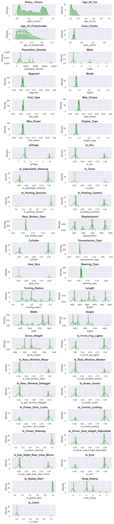

```python
target = [i for i in df.columns]
plt.figure(figsize=(10,45))
for n,column in enumerate(target):
    plot=plt.subplot(22,2,n+1)
    sns.distplot(df[column],color='green')
    plt.title(f'{column.title()}',weight='bold')
    plt.tight_layout()
```

**RadViz** 是一種多元數據可視化算法，它將每個特徵維度均勻地繪制在圓周上，然後在圓的內部繪制點，使點在從中心到每個弧的軸上的值歸一化。這種機制允許有多少維度就有多少維度，可以很容易地適應一個圓，大大擴展了可視化的維度。 可以使用這種方法來檢測類之間的可分離性。如

- 是否有機會從特徵集中學習，
- 檢查是否有太多的噪音

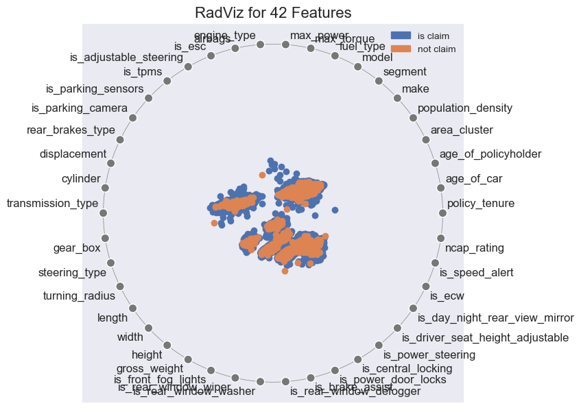

```python
from yellowbrick.features import RadViz


visualizer = RadViz(classes=["is claim","not claim"],
                    features=list(df.columns[:-1]), size=(720, 720))
visualizer.fit(df.iloc[:,:-1].values, df['is_claim'].values)
visualizer.transform(df[:-1].values)
visualizer.poof()
```

上圖看起來標籤的分類沒有很明確，故不期待結果準確區分is_claim，本身是具有偏大難度

之後嘗試接著處理資料不平衡  
為了避免受到噪音干擾，同時採用`ENN`(Edited Nearest Neighbor)和`Borderline Smote`進行採樣

- ENN可以改為Tomek Link Removal，Borderline Smote可以改為單純Smote
- 也可以試著採用集成方法Ensemble(BalanceCascade)
- http://www.17bigdata.com/聊聊样本采样技术/

採樣前得先對數據標準化，標準化之前先分好訓練集&測試集

```python
X = df.iloc[:, :-1]
y = df['is_claim']
X_train, X_test, y_train, y_test = train_test_split(X, y, test_size=0.20, random_state=42)
```

```python
from sklearn.preprocessing import StandardScaler
standard_scaler = StandardScaler()
X_train = pd.DataFrame(standard_scaler.fit_transform(X_train), columns=X_train.columns) #先fit
X_test = pd.DataFrame(standard_scaler.transform(X_test), columns=X_test.columns) #再transform
X_train
```

|  | policy_tenure | age_of_car | age_of_policyholder | area_cluster | population_density | make | segment | model | fuel_type | max_torque | ... | is_rear_window_defogger | is_brake_assist | is_power_door_locks | is_central_locking | is_power_steering | is_driver_seat_height_adjustable | is_day_night_rear_view_mirror | is_ecw | is_speed_alert | ncap_rating |
| --- | --- | --- | --- | --- | --- | --- | --- | --- | --- | --- | --- | --- | --- | --- | --- | --- | --- | --- | --- | --- | --- |
| 0 | 0.961522 | 0.722197 | -0.768522 | -0.555800 | 0.902960 | -0.670401 | 0.565697 | 0.401684 | 0.305708 | 0.461719 | ... | -0.733127 | 0.906217 | 0.615846 | 0.615846 | 0.14483 | 0.842545 | 1.275527 | 0.615846 | 0.079311 | 0.172129 |
| 1 | -0.334619 | -0.338786 | 0.638593 | 0.497989 | -0.836112 | -0.670401 | -0.529922 | -0.257067 | -0.715468 | -0.282627 | ... | -0.733127 | -1.103488 | -1.623782 | -1.623782 | 0.14483 | -1.186880 | -0.783990 | -1.623782 | 0.079311 | -1.268494 |
| 2 | -0.783926 | -0.161955 | 0.951285 | 0.648729 | 0.503848 | -0.670401 | -0.615075 | -0.266702 | -0.731289 | -0.293316 | ... | -0.733127 | -1.103488 | -1.623782 | -1.623782 | 0.14483 | -1.186880 | -0.783990 | -1.623782 | 0.079311 | -1.268494 |
| 3 | -0.155696 | 0.191706 | 2.045708 | 0.577300 | 0.462006 | -0.670401 | 0.528439 | 0.193509 | 0.033480 | 0.306969 | ... | -0.733127 | 0.906217 | 0.615846 | 0.615846 | 0.14483 | 0.842545 | 1.275527 | 0.615846 | 0.079311 | 0.172129 |
| 4 | 1.274063 | 0.191706 | 0.013209 | -0.978505 | -0.058838 | 1.090721 | -0.015762 | -0.016314 | 0.141679 | -0.015549 | ... | 1.364020 | 0.906217 | 0.615846 | 0.615846 | 0.14483 | 0.842545 | -0.783990 | 0.615846 | 0.079311 | 0.892441 |
| ... | ... | ... | ... | ... | ... | ... | ... | ... | ... | ... | ... | ... | ... | ... | ... | ... | ... | ... | ... | ... | ... |
| 46868 | 1.490941 | 2.136841 | -0.143137 | 0.398613 | -0.568981 | 1.090721 | 0.000363 | -0.004540 | 0.117799 | -0.002488 | ... | 1.364020 | 0.906217 | 0.615846 | 0.615846 | 0.14483 | 0.842545 | -0.783990 | 0.615846 | 0.079311 | 0.892441 |
| 46869 | -0.402274 | -1.222938 | 0.404074 | 0.627204 | -0.836112 | -0.670401 | -0.718164 | -0.301916 | -0.862031 | -0.332380 | ... | -0.733127 | -1.103488 | -1.623782 | -1.623782 | 0.14483 | -1.186880 | -0.783990 | -1.623782 | 0.079311 | -1.268494 |
| 46870 | 1.395155 | 1.075858 | -1.159387 | 0.351847 | -0.568981 | -0.670401 | 1.760359 | 2.228357 | 1.578413 | 1.745314 | ... | -0.733127 | 0.906217 | 0.615846 | 0.615846 | 0.14483 | 0.842545 | 1.275527 | 0.615846 | 0.079311 | 0.172129 |
| 46871 | -1.421596 | -1.222938 | 1.889361 | -0.181653 | 0.899959 | -0.670401 | -0.589427 | -0.371739 | -0.505056 | -0.409838 | ... | -0.733127 | -1.103488 | -1.623782 | -1.623782 | 0.14483 | -1.186880 | -0.783990 | -1.623782 | 0.079311 | -1.268494 |
| 46872 | -0.913619 | -1.222938 | 0.091382 | -1.075578 | 3.090686 | -0.670401 | -0.541623 | -0.255870 | -0.724668 | -0.281299 | ... | -0.733127 | -1.103488 | -1.623782 | -1.623782 | 0.14483 | -1.186880 | -0.783990 | -1.623782 | 0.079311 | -1.268494 |

46873 rows × 42 columns

#### Base line performance

```
對於主要目標 標籤為1的預測
Precision：0.10040160642570281,             Recall：0.13227513227513227,
        Accuracy：0.867565491936172,        AUC：0.5252728393292108,        f1-score：0.1141552511415525
[[10067   896]
 [  656   100]]
              precision    recall  f1-score   support

           0       0.94      0.92      0.93     10963
           1       0.10      0.13      0.11       756

    accuracy                           0.87     11719
   macro avg       0.52      0.53      0.52     11719
weighted avg       0.88      0.87      0.88     11719
```

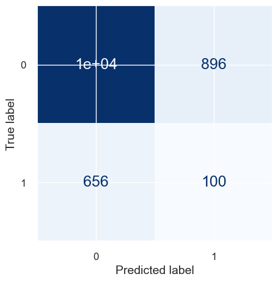

```
The TP rate is: 0.92
The TN rate is: 0.13
The FN rate is: 0.082
The FP rate is: 0.87
```

```python
model = DecisionTreeClassifier(splitter='random')
fit_result(model, X_train, y_train, X_test, y_test)
```

```python
from collections import Counter
from sklearn.model_selection import RepeatedStratifiedKFold
from sklearn.model_selection import cross_val_score

from sklearn.ensemble import GradientBoostingClassifier
from sklearn.tree import DecisionTreeClassifier
from sklearn.metrics import confusion_matrix
from sklearn.metrics import plot_confusion_matrix
```

### CrossCV測試樣本比例

#### *之後記得把kind_sel的模式改看看，也可以試試一般的ENN*

https://blog.csdn.net/mathlxj/article/details/89645321 (mode只刪了626筆，另一個能刪除一萬多)

```python
from imblearn.under_sampling import RepeatedEditedNearestNeighbours
from imblearn.under_sampling import EditedNearestNeighbours
from imblearn.over_sampling import BorderlineSMOTE
from imblearn.over_sampling import SMOTE
from imblearn.pipeline import Pipeline


model = DecisionTreeClassifier(splitter='random')
print("before data balancing：",Counter(y_train))
print()

for i in np.linspace(0.2, 1, 9):
    for j in range(3, 9, 2):
        renn = RepeatedEditedNearestNeighbours()#kind_sel='mode'
        BDsmote = BorderlineSMOTE(m_neighbors=j, sampling_strategy=i)
        steps = [('under(renn)', renn), ('over(BDsmote)', BDsmote)]
        pipeline = Pipeline(steps=steps)
        X_cv, y_cv = pipeline.fit_resample(X_train, y_train)

        #重複兩次 5-fold來評分
        cv = RepeatedStratifiedKFold(n_splits=5, n_repeats=2, random_state=42)
        scores = cross_val_score(model, X_cv, y_cv, scoring='f1_macro', cv=cv) #n_jobs為一次運行多少processor
        print(f'ratio={i}, m={j}, Mean f1_macro: %.3f' % np.mean(scores))
    print("after data balancing:",Counter(y_cv))
    print()
    #print("after data balancing:",Counter(y_cv))
```

```
before data balancing： Counter({0: 43881, 1: 2992})

ratio=0.2, m=3, Mean f1_macro: 0.732
ratio=0.2, m=5, Mean f1_macro: 0.727
ratio=0.2, m=7, Mean f1_macro: 0.723
after data balancing: Counter({0: 32783, 1: 6556})

ratio=0.30000000000000004, m=3, Mean f1_macro: 0.787
ratio=0.30000000000000004, m=5, Mean f1_macro: 0.787
ratio=0.30000000000000004, m=7, Mean f1_macro: 0.785
after data balancing: Counter({0: 32783, 1: 9834})

ratio=0.4, m=3, Mean f1_macro: 0.820
ratio=0.4, m=5, Mean f1_macro: 0.819
ratio=0.4, m=7, Mean f1_macro: 0.814
after data balancing: Counter({0: 32783, 1: 13113})

ratio=0.5, m=3, Mean f1_macro: 0.847
ratio=0.5, m=5, Mean f1_macro: 0.839
ratio=0.5, m=7, Mean f1_macro: 0.840
after data balancing: Counter({0: 32783, 1: 16391})

ratio=0.6000000000000001, m=3, Mean f1_macro: 0.861
ratio=0.6000000000000001, m=5, Mean f1_macro: 0.852
ratio=0.6000000000000001, m=7, Mean f1_macro: 0.851
after data balancing: Counter({0: 32783, 1: 19669})

ratio=0.7, m=3, Mean f1_macro: 0.866
ratio=0.7, m=5, Mean f1_macro: 0.865
ratio=0.7, m=7, Mean f1_macro: 0.857
after data balancing: Counter({0: 32783, 1: 22948})

ratio=0.8, m=3, Mean f1_macro: 0.879
ratio=0.8, m=5, Mean f1_macro: 0.867
ratio=0.8, m=7, Mean f1_macro: 0.865
after data balancing: Counter({0: 32783, 1: 26226})

ratio=0.9000000000000001, m=3, Mean f1_macro: 0.887
ratio=0.9000000000000001, m=5, Mean f1_macro: 0.878
ratio=0.9000000000000001, m=7, Mean f1_macro: 0.872
after data balancing: Counter({0: 32783, 1: 29504})

ratio=1.0, m=3, Mean f1_macro: 0.890
ratio=1.0, m=5, Mean f1_macro: 0.882
ratio=1.0, m=7, Mean f1_macro: 0.879
after data balancing: Counter({0: 32783, 1: 32783})
```

發現在樣本數為1:1，BorderlineSMOTE m=3的情況下會得到較好的f1_macro值  
**注意:** 此結果是基於兩label的資料分布有改變後的結果，才會有此好的結果在f1_macro

```python
def fit_result(model, X_train, y_train, X_test, y_test):
    model.fit(X_train, y_train)
    predicted_y = model.predict(X_test)
    true_y = y_test

    print("對於主要目標 標籤為1的預測")
    print(f"Precision：{metrics.precision_score(true_y, predicted_y)}, \
            Recall：{metrics.recall_score(true_y, predicted_y)},\n \
       Accuracy：{metrics.accuracy_score(true_y, predicted_y)}, \
       AUC：{metrics.roc_auc_score(true_y, model.predict_proba(X_test)[:,1])}, \
       f1-score：{metrics.f1_score(true_y, predicted_y)}")
    cm = confusion_matrix(true_y, predicted_y)
    print(cm)
    print(metrics.classification_report(true_y, predicted_y))

    #此處-1是先的label容易搞混，但我們就照平常的方法來不管此例是-1還是1
    fig, ax = plt.subplots(figsize=(5, 5))
    plot_confusion_matrix(model, X_test, y_test,  cmap=plt.cm.Blues, colorbar=False, ax=ax)
    plt.show()

    #已驗算過
    print('The TP rate is: {0:4.2}'.format(float(cm[0][0])/np.sum(cm[0])))
    print('The TN rate is: {0:4.2}'.format(float(cm[1][1])/np.sum(cm[1])))
    print('The FN rate is: {0:4.2}'.format(1- float(cm[0][0])/np.sum(cm[0]))) #FN = 1-TP
    print('The FP rate is: {0:4.2}'.format(1- float(cm[1][1])/np.sum(cm[1]))) #FP = 1-TN
```

正式將訓練資料重新取樣 -> X_train_sm, y_train_sm, X_test, y_test  
再看一次結果分佈，發現預測為`1`的比例提高了，但是是以數量換得的recall

```
對於主要目標 標籤為1的預測
Precision：0.07863340563991324,             Recall：0.1917989417989418,
        Accuracy：0.8028842051369571,        AUC：0.5184115570072881,        f1-score：0.11153846153846156
[[9264 1699]
 [ 611  145]]
              precision    recall  f1-score   support

           0       0.94      0.85      0.89     10963
           1       0.08      0.19      0.11       756

    accuracy                           0.80     11719
   macro avg       0.51      0.52      0.50     11719
weighted avg       0.88      0.80      0.84     11719
```

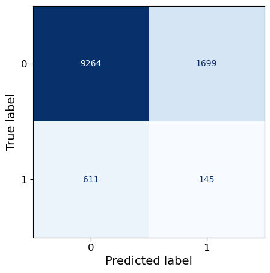

```
The TP rate is: 0.85
The TN rate is: 0.19
The FN rate is: 0.15
The FP rate is: 0.81
```

```python
renn = EditedNearestNeighbours()#kind_sel='mode'
BDsmote = BorderlineSMOTE(m_neighbors=3, sampling_strategy=1.0)
steps = [('under(renn)', renn), ('over(BDsmote)', BDsmote)]
pipeline = Pipeline(steps=steps)
X_train_sm, y_train_sm = pipeline.fit_resample(X_train, y_train)

model = DecisionTreeClassifier(splitter='random')
fit_result(model, X_train_sm, y_train_sm, X_test, y_test)
```

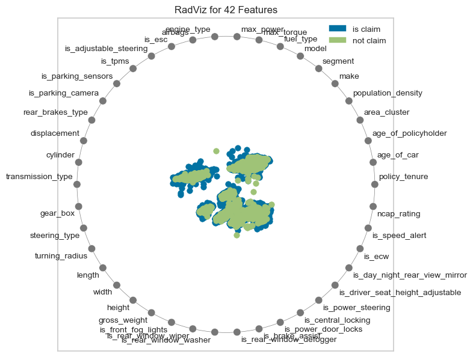

```python
from yellowbrick.features import RadViz


visualizer = RadViz(classes=["is claim","not claim"],
                    features=list(X_train_sm.columns), size=(720, 720))
visualizer.fit(X_train_sm.values, y_train_sm.values)
visualizer.transform(X_train_sm.values)
visualizer.poof()
```

#### 接著進行特徵挑選

單一特徵排名 / 皮爾森相關係數  
特徵的一維排名利用的是一次只考慮單一特徵的排名算法，可以顯示每個特徵的相對排名

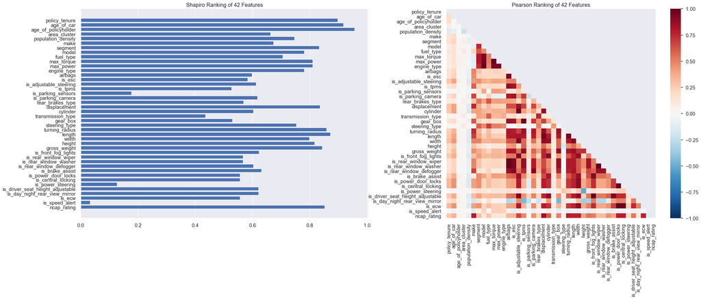

```python
from yellowbrick.features import rank1d, rank2d

_, axes = plt.subplots(ncols=2, figsize=(30, 10))

rank1d(X_train_sm, ax=axes[0], show=False)
rank2d(X_train_sm, ax=axes[1], show=False)
plt.show()
sns.set(font_scale=1.2)
```

```python
from collinearity import SelectNonCollinear  #消除共線性 這個方法可以使用在監督學習以及非監督式學習
```

```python
def UNIP(x, y, threshold):
    selector = SelectNonCollinear(threshold)

    selector.fit(x.values, y.values)
    corr = selector.transform(x.values)

    mask = selector.get_support()

    new_feature = []
    for i in range(len(mask)):
        if mask[i] == True:
            new_feature.append(x.columns[i])

    display(new_feature)

    sns.set(font_scale=0.7)
    heatmap = sns.heatmap(round(x[new_feature].corr(), 2),
                          annot=False,
                          cmap="vlag",
                          vmax=1,
                          vmin=-1)
    heatmap.set_title('Correlation Heatmap', fontdict={'fontsize': 18}, pad=16)

    return new_feature
```

```
['policy_tenure',
 'age_of_car',
 'age_of_policyholder',
 'area_cluster',
 'population_density',
 'make',
 'segment',
 'model',
 'fuel_type',
 'is_parking_sensors',
 'is_parking_camera',
 'rear_brakes_type',
 'cylinder',
 'transmission_type',
 'gear_box',
 'steering_type',
 'height',
 'is_power_door_locks',
 'is_power_steering',
 'is_day_night_rear_view_mirror',
 'is_speed_alert',
 'ncap_rating']
```

```
After removing 20 features, there are 22 features left.
```

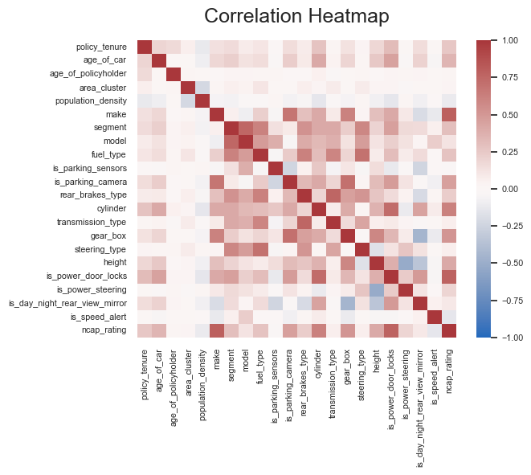

```python
HT = UNIP(X_train_sm, y_train_sm, threshold=0.80) #印出選擇後特徵
print(f'After removing {X_train_sm.shape[1]-len(HT)} features, there are {len(HT)} features left.')
```

```python
X_train_HT = X_train_sm[HT]
X_test_HT = X_test[HT]
```

#### 接著用Lasso進行壓縮

```python
from sklearn.linear_model import Lasso
model = Lasso(alpha=0.005, tol=1e-5)#alpha=0.015, tol=1e-1
model.fit(X_train_HT, y_train_sm)
predicted_y = model.predict(X_test_HT)
#model.coef_
```

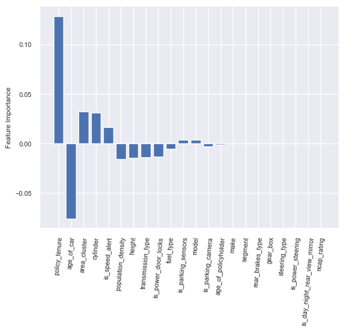

```
the last few features is almost 0, we can discard them.
```

```python
importance = zip(model.coef_, X_train_HT.columns)
imp = list(importance)
imp.sort(key=lambda x: abs(x[0]), reverse=True)
x_pos = np.arange(len(imp))
score = list(map(lambda x: x[0], imp))
name = list(map(lambda x: x[1], imp))

plt.bar(x_pos, score,align='center')
plt.xticks(x_pos, name, rotation = 85)
plt.ylabel('Feature Importance')
plt.show()
print('the last few features is almost 0, we can discard them.')
```

```python
imp_feature = [x[1] for x in imp if abs(x[0])>0]
print(f"there are {len(imp_feature)} features left.")
```

```
there are 14 features left.
```

```python
X_train_final = X_train_HT[imp_feature]
X_test_final = X_test_HT[imp_feature]
y_train_final = y_train_sm
y_test_final = y_test
X_train_final
```

|  | policy_tenure | age_of_car | area_cluster | cylinder | is_speed_alert | population_density | height | transmission_type | is_power_door_locks | fuel_type | is_parking_sensors | model | is_parking_camera | age_of_policyholder |
| --- | --- | --- | --- | --- | --- | --- | --- | --- | --- | --- | --- | --- | --- | --- |
| 0 | 0.961522 | 0.722197 | -0.555800 | 0.772012 | 0.079311 | 0.902960 | -0.294139 | -0.000909 | 0.615846 | 0.305708 | 0.205373 | 0.401684 | -0.799681 | -0.768522 |
| 1 | -0.334619 | -0.338786 | 0.497989 | -1.295317 | 0.079311 | -0.836112 | -0.984956 | -0.073118 | -1.623782 | -0.715468 | 0.205373 | -0.257067 | -0.799681 | 0.638593 |
| 2 | -0.783926 | -0.161955 | 0.648729 | -1.295317 | 0.079311 | 0.503848 | -0.984956 | -0.058424 | -1.623782 | -0.731289 | 0.205373 | -0.266702 | -0.799681 | 0.951285 |
| 3 | -0.155696 | 0.191706 | 0.577300 | 0.772012 | 0.079311 | 0.462006 | -0.294139 | -0.230491 | 0.615846 | 0.033480 | 0.205373 | 0.193509 | -0.799681 | 2.045708 |
| 4 | 1.274063 | 0.191706 | -0.978505 | 0.772012 | 0.079311 | -0.058838 | 1.024694 | -0.232355 | 0.615846 | 0.141679 | 0.205373 | -0.016314 | 1.250499 | 0.013209 |
| ... | ... | ... | ... | ... | ... | ... | ... | ... | ... | ... | ... | ... | ... | ... |
| 72545 | -1.060511 | -1.222938 | 1.077477 | -1.295317 | 0.079311 | -0.836112 | -0.984956 | -0.174351 | -1.623782 | 0.659211 | 0.205373 | -0.147256 | -0.799681 | -1.132409 |
| 72546 | 1.226536 | 1.444844 | 0.525327 | 0.772012 | 0.079311 | -0.568981 | 1.024694 | 1.671032 | 0.615846 | 0.830915 | 0.205373 | 0.887607 | 1.250499 | 0.873112 |
| 72547 | 1.400530 | 1.071505 | -0.039158 | 0.772012 | 0.079311 | -0.568981 | -0.482544 | 0.780719 | 0.615846 | -1.184750 | 0.205373 | 2.989761 | 1.250499 | 1.274223 |
| 72548 | -0.012700 | 1.491886 | 0.513754 | -1.295317 | 0.079311 | 0.462006 | -0.984956 | -0.015833 | -1.623782 | -0.418651 | 0.205373 | -0.327677 | -0.799681 | -0.041933 |
| 72549 | -0.511071 | 0.368536 | -1.218630 | -1.295317 | 0.079311 | 3.090686 | 1.527107 | -0.109052 | 0.615846 | -0.836193 | 0.205373 | -0.776141 | -0.799681 | -0.881696 |

72550 rows × 14 columns

### 特徵挑選完成，開始訓練模型

```
對於主要目標 標籤為1的預測
Precision：0.08473655621944595,             Recall：0.20634920634920634,
        Accuracy：0.8050174929601502,        AUC：0.5263252006388008,        f1-score：0.12013862148633038
[[9278 1685]
 [ 600  156]]
              precision    recall  f1-score   support

           0       0.94      0.85      0.89     10963
           1       0.08      0.21      0.12       756

    accuracy                           0.81     11719
   macro avg       0.51      0.53      0.51     11719
weighted avg       0.88      0.81      0.84     11719
```

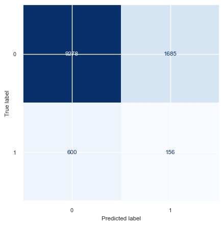

```
The TP rate is: 0.85
The TN rate is: 0.21
The FN rate is: 0.15
The FP rate is: 0.79
```

```python
model = DecisionTreeClassifier(splitter='random')
fit_result(model, X_train_final, y_train_final, X_test_final, y_test_final)
```

### 使用CrossCV測試各種模型參數

使用時長很大，小心執行。

```python
#crossCV挑參數
#https://blog.csdn.net/weixin_41712499/article/details/82882542
#https://ithelp.ithome.com.tw/articles/10267379?sc=iThomeR
# n_estimators: 森林中樹木的數量，預設=100。
# max_features: 劃分時考慮的最大特徵數，預設auto。
# criterion: 亂度的評估標準，gini/entropy。預設為gini。
# max_depth: 樹的最大深度。
# splitter: 特徵劃分點選擇標準，best/random。預設為best。
# random_state: 亂數種子，確保每次訓練結果都一樣，splitter=random 才有用。
# min_samples_split: 至少有多少資料才能再分
# min_samples_leaf: 分完至少有多少資料才能分
from sklearn import metrics
from sklearn.ensemble import RandomForestClassifier
from sklearn.model_selection import cross_val_score
from sklearn.model_selection import RandomizedSearchCV

model = RandomForestClassifier(n_estimators=100, random_state= 42)

n_estimators = [int(x) for x in np.linspace(start=100, stop=2000, num=10)]
max_features = ['auto', 'sqrt']
max_depth = [int(x) for x in np.linspace(5,15, num=8)]
max_depth.append(None)
min_samples_split = [2, 3, 7, 13, 20, 50, 100]
min_samples_leaf = [5, 10, 20, 40, 80]
bootstrap = [True, False]

random_grid = {'n_estimators': n_estimators, 'max_features': max_features,
               'max_depth': max_depth, 'min_samples_split': min_samples_split,
               'min_samples_leaf': min_samples_leaf, 'bootstrap': bootstrap}
random_grid
```

```
{'n_estimators': [100, 311, 522, 733, 944, 1155, 1366, 1577, 1788, 2000],
 'max_features': ['auto', 'sqrt'],
 'max_depth': [5, 6, 7, 9, 10, 12, 13, 15, None],
 'min_samples_split': [2, 3, 7, 13, 20, 50, 100],
 'min_samples_leaf': [5, 10, 20, 40, 80],
 'bootstrap': [True, False]}
```

```python
rdforest = RandomForestClassifier(random_state=42)
rf_random = RandomizedSearchCV(estimator = rdforest, param_distributions=random_grid,
                              n_iter=20, cv=3, verbose=3, scoring='f1_macro', random_state=42)#, n_jobs=-1

rf_random.fit(X_train_final,y_train_final)
rf_random.best_params_
```

```
Fitting 3 folds for each of 20 candidates, totalling 60 fits
[CV 1/3] END bootstrap=False, max_depth=6, max_features=auto, min_samples_leaf=40, min_samples_split=100, n_estimators=100;, score=0.715 total time=   5.3s
[CV 2/3] END bootstrap=False, max_depth=6, max_features=auto, min_samples_leaf=40, min_samples_split=100, n_estimators=100;, score=0.739 total time=   5.3s
[CV 3/3] END bootstrap=False, max_depth=6, max_features=auto, min_samples_leaf=40, min_samples_split=100, n_estimators=100;, score=0.747 total time=   5.9s
[CV 1/3] END bootstrap=True, max_depth=6, max_features=auto, min_samples_leaf=20, min_samples_split=7, n_estimators=100;, score=0.712 total time=   4.2s
[CV 2/3] END bootstrap=True, max_depth=6, max_features=auto, min_samples_leaf=20, min_samples_split=7, n_estimators=100;, score=0.739 total time=   4.1s
[CV 3/3] END bootstrap=True, max_depth=6, max_features=auto, min_samples_leaf=20, min_samples_split=7, n_estimators=100;, score=0.747 total time=   4.1s
[CV 1/3] END bootstrap=True, max_depth=15, max_features=sqrt, min_samples_leaf=20, min_samples_split=2, n_estimators=100;, score=0.828 total time=   7.5s
[CV 2/3] END bootstrap=True, max_depth=15, max_features=sqrt, min_samples_leaf=20, min_samples_split=2, n_estimators=100;, score=0.879 total time=   7.3s
[CV 3/3] END bootstrap=True, max_depth=15, max_features=sqrt, min_samples_leaf=20, min_samples_split=2, n_estimators=100;, score=0.885 total time=   7.2s
[CV 1/3] END bootstrap=True, max_depth=15, max_features=auto, min_samples_leaf=80, min_samples_split=3, n_estimators=311;, score=0.778 total time=  20.9s
[CV 2/3] END bootstrap=True, max_depth=15, max_features=auto, min_samples_leaf=80, min_samples_split=3, n_estimators=311;, score=0.816 total time=  20.0s
[CV 3/3] END bootstrap=True, max_depth=15, max_features=auto, min_samples_leaf=80, min_samples_split=3, n_estimators=311;, score=0.822 total time=  19.8s
[CV 1/3] END bootstrap=False, max_depth=None, max_features=auto, min_samples_leaf=5, min_samples_split=100, n_estimators=944;, score=0.867 total time= 2.0min
[CV 2/3] END bootstrap=False, max_depth=None, max_features=auto, min_samples_leaf=5, min_samples_split=100, n_estimators=944;, score=0.928 total time= 1.8min
[CV 3/3] END bootstrap=False, max_depth=None, max_features=auto, min_samples_leaf=5, min_samples_split=100, n_estimators=944;, score=0.929 total time= 1.8min
[CV 1/3] END bootstrap=False, max_depth=15, max_features=auto, min_samples_leaf=10, min_samples_split=3, n_estimators=944;, score=0.855 total time= 1.7min
[CV 2/3] END bootstrap=False, max_depth=15, max_features=auto, min_samples_leaf=10, min_samples_split=3, n_estimators=944;, score=0.905 total time= 1.8min
[CV 3/3] END bootstrap=False, max_depth=15, max_features=auto, min_samples_leaf=10, min_samples_split=3, n_estimators=944;, score=0.915 total time= 1.8min
[CV 1/3] END bootstrap=True, max_depth=None, max_features=auto, min_samples_leaf=10, min_samples_split=100, n_estimators=944;, score=0.839 total time= 1.2min
[CV 2/3] END bootstrap=True, max_depth=None, max_features=auto, min_samples_leaf=10, min_samples_split=100, n_estimators=944;, score=0.894 total time= 1.1min
[CV 3/3] END bootstrap=True, max_depth=None, max_features=auto, min_samples_leaf=10, min_samples_split=100, n_estimators=944;, score=0.899 total time= 1.2min
[CV 1/3] END bootstrap=True, max_depth=None, max_features=sqrt, min_samples_leaf=80, min_samples_split=13, n_estimators=1155;, score=0.782 total time= 1.2min
[CV 2/3] END bootstrap=True, max_depth=None, max_features=sqrt, min_samples_leaf=80, min_samples_split=13, n_estimators=1155;, score=0.822 total time= 1.2min
[CV 3/3] END bootstrap=True, max_depth=None, max_features=sqrt, min_samples_leaf=80, min_samples_split=13, n_estimators=1155;, score=0.825 total time= 1.2min
[CV 1/3] END bootstrap=True, max_depth=5, max_features=sqrt, min_samples_leaf=10, min_samples_split=20, n_estimators=1366;, score=0.701 total time=  47.3s
```

[output cut: 35 more lines]

```
{'n_estimators': 944,
 'min_samples_split': 100,
 'min_samples_leaf': 5,
 'max_features': 'auto',
 'max_depth': None,
 'bootstrap': False}
```

```
對於主要目標 標籤為1的預測
Precision：0.09403669724770643,             Recall：0.05423280423280423,
        Accuracy：0.9052820206502261,        AUC：0.6040526769455894,        f1-score：0.06879194630872483
[[10568   395]
 [  715    41]]
              precision    recall  f1-score   support

           0       0.94      0.96      0.95     10963
           1       0.09      0.05      0.07       756

    accuracy                           0.91     11719
   macro avg       0.52      0.51      0.51     11719
weighted avg       0.88      0.91      0.89     11719
```

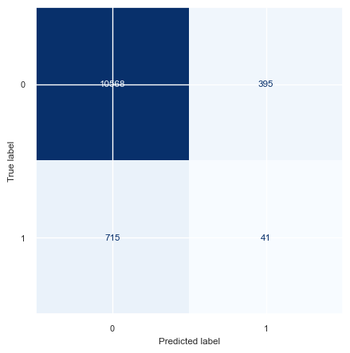

```
The TP rate is: 0.96
The TN rate is: 0.054
The FN rate is: 0.036
The FP rate is: 0.95
```

```python
rdforest = RandomForestClassifier(rf_random.best_params_, random_state=42)
fit_result(model, X_train_final, y_train_final, X_test_final, y_test_final)
```

```python
#adaboost
rf_random.best_params_
```

```
{'n_estimators': 944,
 'min_samples_split': 100,
 'min_samples_leaf': 5,
 'max_features': 'auto',
 'max_depth': None,
 'bootstrap': False}
```

```python
rdm_forest = RandomForestClassifier(n_estimators=944, random_state=42)
rdm_forest.fit(X_train_final, y_train_final)
importances = rdm_forest.feature_importances_
importances
```

```
array([0.16340288, 0.17332761, 0.10710016, 0.00916298, 0.0009588 ,
       0.10659063, 0.03148214, 0.0864985 , 0.00712506, 0.09158155,
       0.00179089, 0.09770118, 0.00900958, 0.11426804])
```

[figure not shown]

```python
rdm_forest = RandomForestClassifier(n_estimators=944, random_state=42)
rdm_forest.fit(X_train_final, y_train_final)
importances = rdm_forest.feature_importances_
importanceRD = zip(importances, X_train_final.columns)
imp = list(importanceRD)
imp.sort(key=lambda x: abs(x[0]), reverse=True)
x_pos = np.arange(len(imp))
score = list(map(lambda x: x[0], imp))
name = list(map(lambda x: x[1], imp))
plt.bar(x_pos, score,align='center')
plt.xticks(x_pos, name, rotation = 85)
plt.ylabel('Feature Importance In RDforest')
plt.show()
```

## 主成分分析PCA+Ont hot encoding

```python
np.shape(X_train)[1]
```

```
42
```

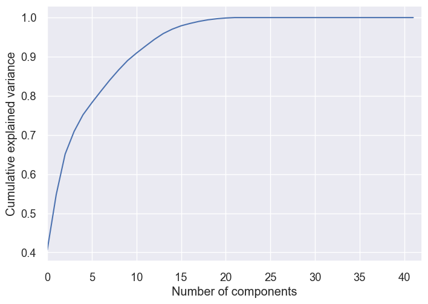

```python
from sklearn.preprocessing import OneHotEncoder
from sklearn.decomposition import PCA
pca = PCA(n_components=np.shape(X_train)[1]).fit(X_train)

plt.plot(np.cumsum(pca.explained_variance_ratio_))
plt.xlim(0, np.shape(X_train)[1], 1)
plt.xlabel('Number of components')
plt.ylabel('Cumulative explained variance')
```

```python
#選擇15個主成份可解釋超過95% variance
pca = PCA(n_components=15)
pca.fit(X_train)
X_train_PCA = pca.transform(X_train)
X_test_PCA = pca.transform(X_test)

X_train_PCA = pd.DataFrame(
    X_train_PCA,
    columns=['PC-' + str(pc) for pc in list(range(1, X_train_PCA.shape[1] + 1))])
X_test_PCA = pd.DataFrame(
    X_test_PCA,
    columns=['PC-' + str(pc) for pc in list(range(1, X_test_PCA.shape[1] + 1))])

X_train_PCA
```

|  | PC-1 | PC-2 | PC-3 | PC-4 | PC-5 | PC-6 | PC-7 | PC-8 | PC-9 | PC-10 | PC-11 | PC-12 | PC-13 | PC-14 | PC-15 |
| --- | --- | --- | --- | --- | --- | --- | --- | --- | --- | --- | --- | --- | --- | --- | --- |
| 0 | 0.493901 | 2.114988 | -2.675594 | -0.478448 | 0.158548 | -0.315094 | 0.861237 | 0.108108 | -0.326087 | 0.602008 | -1.017573 | 0.424589 | -0.298876 | 0.517727 | -0.542832 |
| 1 | -5.207427 | -0.087541 | 1.665907 | -0.394709 | -0.579053 | 0.631603 | -1.046583 | 0.328629 | 0.043394 | -0.224240 | 0.079796 | -0.235132 | 0.694072 | 0.203334 | 0.032114 |
| 2 | -5.269675 | -0.150404 | 1.678508 | -0.426818 | -0.693047 | 0.088324 | -0.389760 | 0.378019 | -0.305271 | -0.239112 | 0.566610 | 0.770031 | 0.871513 | 0.253339 | 0.105538 |
| 3 | 0.278757 | 1.726575 | -2.708001 | -0.724122 | -0.129088 | 0.233667 | -0.236233 | 0.709235 | -1.232157 | -0.391420 | 1.580191 | 0.535482 | 0.261463 | 0.387223 | -0.202204 |
| 4 | 5.574404 | -2.133919 | 1.245618 | -0.594400 | -0.005262 | -0.394485 | -0.103663 | -0.257623 | -0.903457 | 0.031366 | -0.861757 | -0.525226 | -0.445828 | 0.015820 | -0.363084 |
| ... | ... | ... | ... | ... | ... | ... | ... | ... | ... | ... | ... | ... | ... | ... | ... |
| 46868 | 5.825896 | -1.995566 | 1.057475 | -0.368103 | 0.475441 | 0.652870 | -0.887052 | -0.353757 | -0.496877 | 0.483261 | -1.324320 | 0.444161 | 1.083884 | 0.240646 | -0.324141 |
| 46869 | -5.370776 | -0.322305 | 1.678203 | -0.538284 | -0.735114 | 0.537286 | -1.106087 | 0.346193 | 0.363762 | -0.441817 | 0.261942 | -0.284811 | -0.093726 | 0.116794 | 0.062570 |
| 46870 | 1.567146 | 5.494182 | -1.529043 | 0.161698 | 0.682789 | 0.693736 | -0.103285 | -0.065954 | 0.325844 | 0.679997 | -1.494908 | -0.019854 | -0.071490 | 0.284650 | -0.151635 |
| 46871 | -5.429856 | -0.107041 | 1.842862 | -0.273282 | -1.136005 | -0.569175 | 0.146092 | 0.704142 | -0.924927 | -0.711571 | 1.579425 | 0.168277 | 0.416316 | 0.011397 | -0.024517 |
| 46872 | -5.443006 | -0.206020 | 1.874960 | -0.504773 | -1.082319 | -1.861005 | 1.867180 | 0.216192 | -0.827341 | -0.071061 | 0.197805 | 1.205339 | -0.456024 | 0.366907 | 0.047561 |

46873 rows × 15 columns

```
對於主要目標 標籤為1的預測
Precision：0.08125,             Recall：0.10317460317460317,
        Accuracy：0.8668828398327503,        AUC：0.5113610861353268,        f1-score：0.0909090909090909
[[10081   882]
 [  678    78]]
              precision    recall  f1-score   support

           0       0.94      0.92      0.93     10963
           1       0.08      0.10      0.09       756

    accuracy                           0.87     11719
   macro avg       0.51      0.51      0.51     11719
weighted avg       0.88      0.87      0.87     11719
```

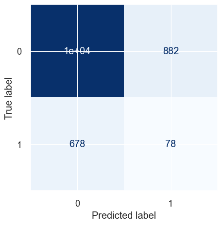

```
The TP rate is: 0.92
The TN rate is:  0.1
The FN rate is: 0.08
The FP rate is:  0.9
```

```python
model = DecisionTreeClassifier(splitter='random')
fit_result(model, X_train_PCA, y_train, X_test_PCA, y_test)
```

#### 現在用數據增強過後的資料

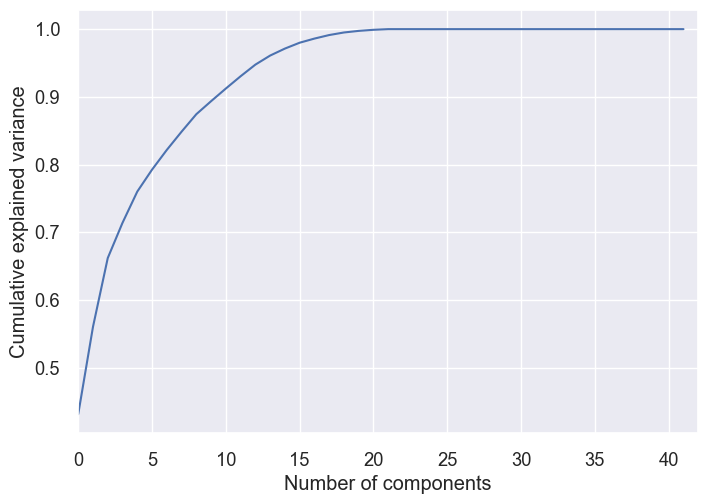

```python
pca_sm = PCA(n_components=np.shape(X_train_sm)[1]).fit(X_train_sm)

plt.plot(np.cumsum(pca_sm.explained_variance_ratio_))
plt.xlim(0, np.shape(X_train_sm)[1], 1)
plt.xlabel('Number of components')
plt.ylabel('Cumulative explained variance')
```

```python
#選擇15個主成份可解釋超過95% variance
pca_sm = PCA(n_components=15)
pca.fit(X_train_sm)
X_train_PCA_sm = pca.transform(X_train_sm)
X_test_PCA_sm = pca.transform(X_test)

X_train_PCA_sm = pd.DataFrame(
    X_train_PCA_sm,
    columns=['PC-' + str(pc) for pc in list(range(1, X_train_PCA_sm.shape[1] + 1))])
X_test_PCA_sm = pd.DataFrame(
    X_test_PCA_sm,
    columns=['PC-' + str(pc) for pc in list(range(1, X_test_PCA_sm.shape[1] + 1))])

X_train_PCA_sm
```

|  | PC-1 | PC-2 | PC-3 | PC-4 | PC-5 | PC-6 | PC-7 | PC-8 | PC-9 | PC-10 | PC-11 | PC-12 | PC-13 | PC-14 | PC-15 |
| --- | --- | --- | --- | --- | --- | --- | --- | --- | --- | --- | --- | --- | --- | --- | --- |
| 0 | 0.421573 | 3.232832 | -0.803417 | -0.462474 | -0.049267 | -0.429600 | 1.067287 | -0.333979 | -0.153231 | -0.205905 | 1.026230 | 0.523982 | 0.066553 | 0.619389 | -0.271018 |
| 1 | -5.266735 | -1.120275 | 1.233415 | -0.086938 | -0.549874 | 0.428887 | -1.157786 | 0.166771 | 0.062953 | -0.041534 | -0.127637 | -0.726781 | 0.511164 | 0.294730 | 0.207369 |
| 2 | -5.343816 | -1.186803 | 1.242016 | -0.089232 | -0.709884 | -0.010469 | -0.697590 | -0.199541 | 0.377784 | 0.739476 | -0.317832 | 0.084490 | 0.928219 | 0.389187 | 0.239316 |
| 3 | 0.226197 | 2.982181 | -1.068273 | -0.665980 | -0.250416 | 0.045939 | -0.679611 | -1.002560 | 0.757891 | 1.538793 | -0.725469 | 0.063702 | 0.122689 | 0.415008 | -0.085741 |
| 4 | 5.569159 | -2.435192 | -0.026976 | -0.535515 | -0.179953 | -0.653725 | -0.002965 | -0.788216 | -0.142791 | -0.804837 | 0.393108 | -0.108861 | -0.303764 | 0.115404 | -0.333903 |
| ... | ... | ... | ... | ... | ... | ... | ... | ... | ... | ... | ... | ... | ... | ... | ... |
| 72545 | -5.302205 | -0.727240 | 1.890466 | 0.899553 | -0.603022 | 0.617425 | -0.328263 | 1.903995 | -0.013522 | 0.061850 | 0.053565 | -0.203604 | -0.179589 | -0.213702 | -0.870417 |
| 72546 | 6.522981 | -0.835084 | 2.407248 | 0.802597 | 0.812222 | 0.923184 | -0.568029 | -0.757433 | 0.249298 | -0.090359 | 0.500463 | -0.448833 | 0.786631 | 0.911214 | 0.770927 |
| 72547 | 1.740559 | 2.198631 | -0.689837 | -1.451229 | -1.084330 | 0.547965 | -0.789638 | -0.958226 | 0.212002 | -1.107927 | -0.278385 | -0.004398 | 1.433719 | -1.711791 | 2.092195 |
| 72548 | -5.107227 | -0.997637 | 1.133316 | 0.127345 | -0.335619 | 0.283777 | -0.186530 | -0.081017 | -0.147046 | 0.031257 | 0.848951 | 0.046684 | 2.146516 | 0.842488 | 0.047408 |
| 72549 | -2.982209 | -1.187534 | -1.073338 | 0.040899 | 1.364122 | -2.295269 | 2.162173 | -1.242720 | -1.347348 | 1.142557 | 0.609838 | 1.573336 | 0.244153 | -0.039527 | 1.678052 |

72550 rows × 15 columns

```python
X_test_PCA_sm #原本五萬多筆資料的1/5，沒有經過特徵增強，標sm只是在此方便辨識
```

|  | PC-1 | PC-2 | PC-3 | PC-4 | PC-5 | PC-6 | PC-7 | PC-8 | PC-9 | PC-10 | PC-11 | PC-12 | PC-13 | PC-14 | PC-15 |
| --- | --- | --- | --- | --- | --- | --- | --- | --- | --- | --- | --- | --- | --- | --- | --- |
| 0 | 0.887259 | 0.063991 | -3.607152 | 2.066939 | 0.338426 | -0.406478 | -0.303560 | 1.997307 | 2.835162 | -0.542015 | -1.186188 | -0.447260 | 0.548918 | -0.837797 | 0.473788 |
| 1 | -0.598898 | 1.042406 | -3.262872 | -2.052541 | -0.870503 | -0.620420 | 0.392398 | 1.150132 | -0.672732 | 0.668256 | -0.691139 | -0.604514 | -0.807093 | 0.786324 | 0.972918 |
| 2 | 5.410069 | -2.520170 | 0.357105 | -0.301562 | -0.295684 | -0.169816 | -0.021724 | 1.614480 | -0.512086 | 0.464086 | -0.794682 | -0.165498 | -0.822969 | -0.043483 | -0.244256 |
| 3 | -5.475467 | -1.307015 | 1.382420 | 0.306756 | -0.964449 | -0.501402 | 0.570228 | 0.484406 | 0.282648 | 0.083376 | -0.286789 | -0.862839 | -0.366618 | 0.146792 | -0.046017 |
| 4 | 0.395589 | 3.320351 | -0.692020 | -0.457064 | -0.009325 | 0.425964 | -0.893096 | -0.452065 | 0.342993 | 0.144702 | 0.068153 | -0.090449 | -0.871937 | 0.156649 | -0.327451 |
| ... | ... | ... | ... | ... | ... | ... | ... | ... | ... | ... | ... | ... | ... | ... | ... |
| 11714 | -4.352099 | -3.078443 | 0.001175 | -5.009813 | 5.048548 | 2.987228 | 2.040861 | -0.180138 | 1.762862 | 0.791366 | -1.743699 | -1.071150 | 0.727082 | -0.351228 | -0.217462 |
| 11715 | -5.403743 | -1.282838 | 1.351061 | -0.001931 | -0.864299 | -0.789887 | 1.155462 | 0.806541 | -0.309522 | -0.008211 | 0.297948 | 0.132973 | 0.445073 | 0.438620 | 0.125643 |
| 11716 | -5.302598 | -1.130145 | 1.193703 | -0.034631 | -0.544504 | 0.083027 | -0.700983 | 0.131812 | -0.069846 | -0.946084 | 1.155578 | 1.048829 | -0.236330 | 0.187385 | -0.132358 |
| 11717 | 5.667948 | -2.399015 | -0.184198 | -0.547917 | 0.144152 | 0.117460 | -0.400048 | 0.308805 | -0.800848 | -0.729869 | 0.774132 | 0.178847 | 0.665830 | 0.408926 | -0.274751 |
| 11718 | -5.220765 | -1.026591 | 1.302927 | -0.031934 | -0.503918 | 0.533390 | -1.882181 | -0.946114 | 0.665449 | -0.347213 | 0.102687 | -0.326006 | -0.130331 | 0.161516 | 0.214682 |

11719 rows × 15 columns

```
對於主要目標 標籤為1的預測
Precision：0.08222550467749877,             Recall：0.2208994708994709,
        Accuracy：0.7906817987882925,        AUC：0.5254365091430676,        f1-score：0.11984212414782922
[[9099 1864]
 [ 589  167]]
              precision    recall  f1-score   support

           0       0.94      0.83      0.88     10963
           1       0.08      0.22      0.12       756

    accuracy                           0.79     11719
   macro avg       0.51      0.53      0.50     11719
weighted avg       0.88      0.79      0.83     11719
```

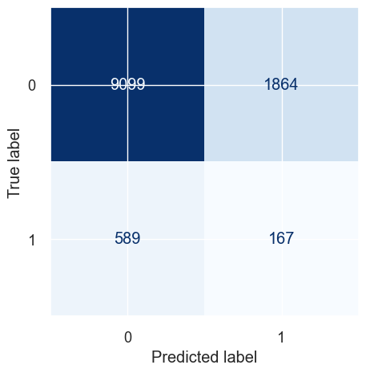

```
The TP rate is: 0.83
The TN rate is: 0.22
The FN rate is: 0.17
The FP rate is: 0.78
```

```python
model = DecisionTreeClassifier(splitter='random')
fit_result(model, X_train_PCA_sm, y_train_sm, X_test_PCA_sm, y_test)
```

```python
X_train
```

|  | policy_tenure | age_of_car | age_of_policyholder | area_cluster | population_density | make | segment | model | fuel_type | max_torque | ... | is_rear_window_defogger | is_brake_assist | is_power_door_locks | is_central_locking | is_power_steering | is_driver_seat_height_adjustable | is_day_night_rear_view_mirror | is_ecw | is_speed_alert | ncap_rating |
| --- | --- | --- | --- | --- | --- | --- | --- | --- | --- | --- | --- | --- | --- | --- | --- | --- | --- | --- | --- | --- | --- |
| 0 | 0.961522 | 0.722197 | -0.768522 | -0.555800 | 0.902960 | -0.670401 | 0.565697 | 0.401684 | 0.305708 | 0.461719 | ... | -0.733127 | 0.906217 | 0.615846 | 0.615846 | 0.14483 | 0.842545 | 1.275527 | 0.615846 | 0.079311 | 0.172129 |
| 1 | -0.334619 | -0.338786 | 0.638593 | 0.497989 | -0.836112 | -0.670401 | -0.529922 | -0.257067 | -0.715468 | -0.282627 | ... | -0.733127 | -1.103488 | -1.623782 | -1.623782 | 0.14483 | -1.186880 | -0.783990 | -1.623782 | 0.079311 | -1.268494 |
| 2 | -0.783926 | -0.161955 | 0.951285 | 0.648729 | 0.503848 | -0.670401 | -0.615075 | -0.266702 | -0.731289 | -0.293316 | ... | -0.733127 | -1.103488 | -1.623782 | -1.623782 | 0.14483 | -1.186880 | -0.783990 | -1.623782 | 0.079311 | -1.268494 |
| 3 | -0.155696 | 0.191706 | 2.045708 | 0.577300 | 0.462006 | -0.670401 | 0.528439 | 0.193509 | 0.033480 | 0.306969 | ... | -0.733127 | 0.906217 | 0.615846 | 0.615846 | 0.14483 | 0.842545 | 1.275527 | 0.615846 | 0.079311 | 0.172129 |
| 4 | 1.274063 | 0.191706 | 0.013209 | -0.978505 | -0.058838 | 1.090721 | -0.015762 | -0.016314 | 0.141679 | -0.015549 | ... | 1.364020 | 0.906217 | 0.615846 | 0.615846 | 0.14483 | 0.842545 | -0.783990 | 0.615846 | 0.079311 | 0.892441 |
| ... | ... | ... | ... | ... | ... | ... | ... | ... | ... | ... | ... | ... | ... | ... | ... | ... | ... | ... | ... | ... | ... |
| 46868 | 1.490941 | 2.136841 | -0.143137 | 0.398613 | -0.568981 | 1.090721 | 0.000363 | -0.004540 | 0.117799 | -0.002488 | ... | 1.364020 | 0.906217 | 0.615846 | 0.615846 | 0.14483 | 0.842545 | -0.783990 | 0.615846 | 0.079311 | 0.892441 |
| 46869 | -0.402274 | -1.222938 | 0.404074 | 0.627204 | -0.836112 | -0.670401 | -0.718164 | -0.301916 | -0.862031 | -0.332380 | ... | -0.733127 | -1.103488 | -1.623782 | -1.623782 | 0.14483 | -1.186880 | -0.783990 | -1.623782 | 0.079311 | -1.268494 |
| 46870 | 1.395155 | 1.075858 | -1.159387 | 0.351847 | -0.568981 | -0.670401 | 1.760359 | 2.228357 | 1.578413 | 1.745314 | ... | -0.733127 | 0.906217 | 0.615846 | 0.615846 | 0.14483 | 0.842545 | 1.275527 | 0.615846 | 0.079311 | 0.172129 |
| 46871 | -1.421596 | -1.222938 | 1.889361 | -0.181653 | 0.899959 | -0.670401 | -0.589427 | -0.371739 | -0.505056 | -0.409838 | ... | -0.733127 | -1.103488 | -1.623782 | -1.623782 | 0.14483 | -1.186880 | -0.783990 | -1.623782 | 0.079311 | -1.268494 |
| 46872 | -0.913619 | -1.222938 | 0.091382 | -1.075578 | 3.090686 | -0.670401 | -0.541623 | -0.255870 | -0.724668 | -0.281299 | ... | -0.733127 | -1.103488 | -1.623782 | -1.623782 | 0.14483 | -1.186880 | -0.783990 | -1.623782 | 0.079311 | -1.268494 |

46873 rows × 42 columns

```
對於主要目標 標籤為1的預測
Precision：0.10056657223796034,             Recall：0.18783068783068782,
        Accuracy：0.8392354296441676,        AUC：0.6340431041014821,        f1-score：0.1309963099630996
[[9693 1270]
 [ 614  142]]
              precision    recall  f1-score   support

           0       0.94      0.88      0.91     10963
           1       0.10      0.19      0.13       756

    accuracy                           0.84     11719
   macro avg       0.52      0.54      0.52     11719
weighted avg       0.89      0.84      0.86     11719
```

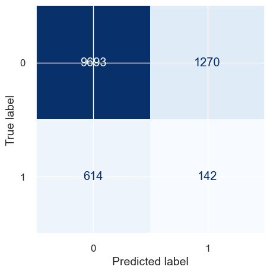

```
The TP rate is: 0.88
The TN rate is: 0.19
The FN rate is: 0.12
The FP rate is: 0.81
```

```python
from sklearn.ensemble import RandomForestClassifier

CSRF= RandomForestClassifier(n_estimators=1000 ,min_samples_leaf=20, class_weight='balanced')
fit_result(CSRF, X_train_final, y_train_final, X_test_final, y_test_final)
```

```
對於主要目標 標籤為1的預測
Precision：0.07202272266179753,             Recall：0.9391534391534392,
        Accuracy：0.21546207014250363,        AUC：0.636778736751372,        f1-score：0.13378556623327684
[[1815 9148]
 [  46  710]]
              precision    recall  f1-score   support

           0       0.98      0.17      0.28     10963
           1       0.07      0.94      0.13       756

    accuracy                           0.22     11719
   macro avg       0.52      0.55      0.21     11719
weighted avg       0.92      0.22      0.27     11719
```

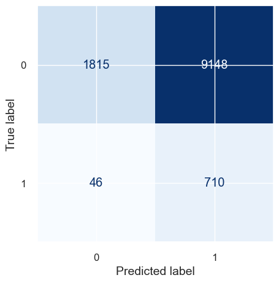

```
The TP rate is: 0.17
The TN rate is: 0.94
The FN rate is: 0.83
The FP rate is: 0.061
```

```python
weight={0:1, 1:500}
CSRF= RandomForestClassifier(n_estimators=1500 ,min_samples_leaf=20, class_weight=weight)
fit_result(CSRF, X_train_final, y_train_final, X_test_final, y_test_final)
```

```
對於主要目標 標籤為1的預測
Precision：0.06878980891719745,             Recall：0.9285714285714286,
        Accuracy：0.18448673094973975,        AUC：0.5918927880069903,        f1-score：0.12809050269136027
[[1460 9503]
 [  54  702]]
              precision    recall  f1-score   support

           0       0.96      0.13      0.23     10963
           1       0.07      0.93      0.13       756

    accuracy                           0.18     11719
   macro avg       0.52      0.53      0.18     11719
weighted avg       0.91      0.18      0.23     11719
```

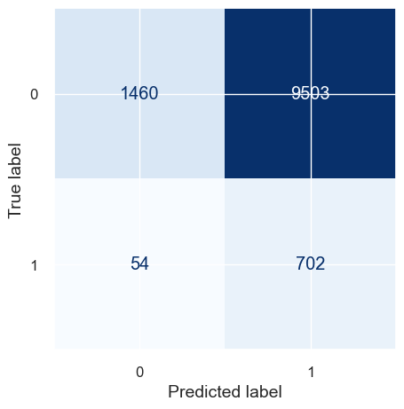

```
The TP rate is: 0.13
The TN rate is: 0.93
The FN rate is: 0.87
The FP rate is: 0.071
```

```python
from sklearn.linear_model import LogisticRegression
weight={0:1, 1:3}
LG = LogisticRegression(class_weight=weight)
fit_result(LG, X_train_final, y_train_final, X_test_final, y_test_final)
```